# Analiza mieszkań na obszarze miasta Gdańsk

Veronika Krasnianska, Olena Dovhopola

2026-01-31

## Wprowadzenie

Rynek nieruchomości mieszkaniowych w dużych miastach charakteryzuje się znaczną złożonością oraz silnym zróżnicowaniem cen i cech lokali. Miasto Gdańsk, jako jeden z głównych ośrodków miejskich w Polsce, stanowi interesujący obszar badań ze względu na dynamiczny rozwój urbanistyczny, zróżnicowaną strukturę dzielnic oraz istotny wpływ czynników lokalizacyjnych na ceny mieszkań.

Celem projektu jest analiza rynku mieszkań na obszarze miasta Gdańsk z wykorzystaniem narzędzi i metod analizy danych dostępnych w środowisku RStudio, żeby odpowiedzieć na główne pytania badawcze. Badanie obejmuje eksploracyjną analizę danych, identyfikację zależności pomiędzy wybranymi cechami mieszkań (takimi jak metraż, liczba pokoi, lokalizacja czy odległość od centrum) oraz ocenę ich wpływu na poziom cen. Szczególną uwagę poświęcono analizie rozkładów zmiennych, zależności korelacyjnych oraz wizualizacji danych przestrzennych.

Projekt realizowany jest w ramach przedmiotu „Analiza danych w R” i ma na celu praktyczne zastosowanie poznanych metod statystycznych oraz narzędzi programistycznych języka R. Uzyskane wyniki pozwalają na lepsze zrozumienie mechanizmów kształtujących ceny mieszkań w Gdańsku oraz stanowią podstawę do dalszych, bardziej zaawansowanych analiz ekonometrycznych i predykcyjnych.

Opis zmiennych zawartych w zbiorze danych

| Zmienna | Opis zmiennej |
| --- | --- |
| id | identyfikator nieruchomości |
| city | nazwa miasta, w którym znajduje się nieruchomość |
| type | typ budynku |
| squareMeters | wielkość mieszkania w metrach kwadratowych |
| rooms | liczba pokoi w mieszkaniu |
| floor | piętro, na którym znajduje się mieszkanie |
| floorCount | całkowita liczba pięter w budynku |
| buildYear | rok, w którym budynek został zbudowany |
| latitude | szerokość geograficzna nieruchomości |
| longitude | długość geograficzna nieruchomości |
| centreDistance | odległość od centrum miasta w kilometrach |
| poiCount | liczba interesujących miejsc w promieniu 500 m |
| [poiName]Distance | odległość do najbliższego interesującego punktu (szkoły, przychodnie, poczta, przedszkola, restauracje, uczelnie, apteki) |
| ownership | rodzaj własności nieruchomości |
| condition | stan mieszkania |
| has[features] | czy nieruchomość posiada kluczowe udogodnienia, takie jak przypisane miejsce parkingowe, balkon, winda, ochrona, komórka lokatorska |
| cena | cena ofertowa w złotych polskich |

### Pytania badawcze

Celem analizy jest ocena wpływu lokalizacji oraz standardu technicznego mieszkania na poziom cen na rynku mieszkaniowym w Gdańsku. W szczególności badanie koncentruje się na zależności pomiędzy odległością mieszkania od centrum miasta a ceną oraz sprawdzeniu, czy wybrane cechy standardu technicznego modyfikują tę zależność. W związku z tym sformułowano następujące pytania badawcze: + Czy wzrost odległości mieszkania od centrum miasta wiąże się ze spadkiem cen mieszkań oraz cen za metr kwadratowy? + Czy mieszkania o wyższym standardzie technicznym osiągają wyższe ceny niż mieszkania pozbawione określonych udogodnień? + Czy siła i kierunek zależności pomiędzy odległością od centrum a ceną za metr kwadratowy różnią się w zależności od standardu technicznego mieszkania? + Czy metraż mieszkania jest dodatnio związany z ceną całkowitą oraz ujemnie związany z ceną za metr kwadratowy?

## Przygotowanie i kontrola jakości danych

W niniejszym rozdziale przedstawiono proces przygotowania danych do analizy cen mieszkań w Gdańsku. Obejmuje on wstępne przetwarzanie danych, analizę braków, walidację spójności logicznej oraz identyfikację obserwacji odstających, których celem było zapewnienie jakości i wiarygodności dalszych analiz statystycznych.

### Wstępne przetwarzanie i selekcja danych

W pierwszym etapie dane zostały ograniczone do obserwacji dotyczących miasta Gdańsk, co pozwoliło skoncentrować analizę na jednym, spójnym rynku lokalnym. Następnie przeprowadzono podstawowe czynności przygotowawcze obejmujące kontrolę duplikatów, selekcję zmiennych istotnych analitycznie, standaryzację typów danych oraz utworzenie zmiennej ceny za metr kwadratowy.

W wyniku kontroli nie stwierdzono występowania duplikatów obserwacji, co pozwoliło na zachowanie pełnej liczby rekordów w dalszej analizie.

### Analiza braków danych

W niniejszym podrozdziale przeprowadzono analizę występowania braków danych w zbiorze ofert mieszkaniowych zlokalizowanych w Gdańsku. Celem tego etapu było określenie zakresu i struktury braków danych oraz ocena ich potencjalnego wpływu na dalszą analizę statystyczną.

Występowanie braków danych

Podsumowanie dla zmiennych w zbiorze danych (niezaznaczone zmienne nie posiadają braków danych)

| Zmienna | Liczba braków | Udział braków [%] |
| --- | --- | --- |
| type | 503 | 25.3 |
| floor | 371 | 18.7 |
| buildYear | 225 | 11.3 |
| hasElevator | 88 | 4.43 |
| collegeDistance | 69 | 3.47 |
| clinicDistance | 7 | 0.352 |
| postOfficeDistance | 7 | 0.352 |
| kindergartenDistance | 7 | 0.352 |
| restaurantDistance | 7 | 0.352 |
| pharmacyDistance | 7 | 0.352 |
| floorCount | 5 | 0.252 |
| schoolDistance | 4 | 0.201 |

Ze względu na występowanie braków w wybranych zmiennych podjęto decyzję o zastosowaniu imputacji wielokrotnej w kolejnym etapie, aby ograniczyć utratę informacji i zachować liczebność próby.

### Walidacja spójności danych

W celu oceny poprawności logicznej i dziedzinowej danych przeprowadzono walidację spójności z wykorzystaniem zestawu reguł twardych oraz miękkich. Reguły twarde obejmowały jednoznaczne ograniczenia dziedzinowe i logiczne, natomiast reguły miękkie miały charakter heurystyczny i służyły identyfikacji obserwacji potencjalnie nietypowych.

Walidacja reguł twardych

Podsumowanie spełnienia reguł dla zbioru danych

| ID | Status | Liczba obserwacji | Spełnione | Naruszone | Braki (NA) | Odsetek naruszeń [%] | Reguła |
| --- | --- | --- | --- | --- | --- | --- | --- |
| V01 | OK | 1986 | 1986 | 0 | 0 | 0 | squareMeters > 0 |
| V02 | OK | 1986 | 1986 | 0 | 0 | 0 | squareMeters - 250 <= 1e-08 |
| V03 | OK | 1986 | 1986 | 0 | 0 | 0 | rooms - 1 >= -1e-08 |
| V04 | OK | 1986 | 1986 | 0 | 0 | 0 | rooms - 8 <= 1e-08 |
| V05 | OK | 1986 | 1986 | 0 | 0 | 0 | squareMeters - rooms * 8 >= -1e-08 |
| V06 | OK | 1986 | 1986 | 0 | 0 | 0 | squareMeters - rooms * 40 <= 1e-08 |
| V07 | OK | 1986 | 1986 | 0 | 0 | 0 | floor - 0 >= -1e-08 \| is.na(floor) |
| V08 | OK | 1986 | 1986 | 0 | 0 | 0 | floorCount - 1 >= -1e-08 \| is.na(floorCount) |
| V09 | OK | 1986 | 1986 | 0 | 0 | 0 | floor - floorCount <= 1e-08 \| is.na(floor) \| is.na(floorCount) |
| V10 | OK | 1986 | 1986 | 0 | 0 | 0 | buildYear - 1850 >= -1e-08 \| is.na(buildYear) |

Walidacja reguł miękkich

Reguły heurystyczne – obserwacje nietypowe (top 10)

| ID | Status | Liczba obserwacji | Spełnione | Oznaczone | Braki (NA) | Odsetek naruszeń [%] | Reguła |
| --- | --- | --- | --- | --- | --- | --- | --- |
| V2 | Nietypowa | 1986 | 1968 | 18 | 0 | 0.91 | floor - 5 < -1e-08 \| buildYear - 1995 < -1e-08 \| hasElevator != "no" \| is.na(floor) \| is.na(buildYear) \| is.na(hasElevator) |
| V1 | OK | 1986 | 1986 | 0 | 0 | 0.00 | buildYear >= 1945 \| floorCount <= 7 \| is.na(buildYear) \| is.na(floorCount) |
| V3 | OK | 1986 | 1986 | 0 | 0 | 0.00 | squareMeters >= 35 \| rooms - 3 < -1e-08 |
| V4 | OK | 1986 | 1986 | 0 | 0 | 0.00 | squareMeters <= 80 \| abs(rooms - 1) > 1e-08 |

Wyniki walidacji reguł twardych nie wykazały istotnych naruszeń spójności danych, co pozwala uznać zbiór za poprawny pod względem podstawowych ograniczeń logicznych i dziedzinowych. Reguły miękkie wskazały jedynie niewielką liczbę obserwacji nietypowych, które pozostawiono w zbiorze danych jako potencjalnie realistyczne przypadki rynkowe.

### Identyfikacja obserwacji odstających

W kolejnym etapie przeprowadzono diagnostykę obserwacji odstających z wykorzystaniem metody IQR. Celem analizy było określenie skali występowania wartości nietypowych w poszczególnych zmiennych numerycznych oraz ocena ich potencjalnego wpływu na dalsze etapy analizy.

Identyfikacja wartości odstających (IQR)

| Zmienna | % obserwacji odstających |
| --- | --- |
| Liczba kondygnacji w budynku | 13.83 |
| Liczba punktów POI w pobliżu | 9.97 |
| Odległość do szkoły [km] | 8.07 |
| Odległość do poczty [km] | 7.93 |
| Cena całkowita [PLN] | 6.65 |
| Piętro | 5.08 |
| Odległość do restauracji [km] | 3.99 |
| Odległość do przedszkola [km] | 3.89 |
| Powierzchnia mieszkania [m²] | 3.37 |
| Liczba pokoi | 3.12 |
| Odległość do przychodni [km] | 2.93 |
| Rok budowy | 2.84 |
| Odległość do apteki [km] | 2.73 |
| Cena za metr kwadratowy [PLN/m²] | 1.01 |
| Długość geograficzna | 0.50 |

Zidentyfikowane obserwacje odstające nie zostały usunięte ze zbioru danych, ponieważ mogą one odzwierciedlać rzeczywiste zróżnicowanie cen i cech mieszkań na rynku nieruchomości.

### Postępowanie z brakami danych i imputacja wielokrotna

W przypadku wybranych zmiennych, dla których występowały braki danych, przeprowadzono procedurę imputacji wielokrotnej w celu ograniczenia utraty informacji. Przed imputacją oceniono mechanizm braków danych, a następnie zastosowano metodę MICE, dostosowując modele imputacyjne do charakteru poszczególnych zmiennych. Poprawność imputacji oceniono na podstawie diagnostyki rozkładów imputowanych wartości.

Wyniki testu MCAR (Little’a)

| Statystyka χ² | Stopnie swobody | Wartość p | Liczba wzorców braków danych |
| --- | --- | --- | --- |
| 3314.3 | 659 | 0 | 31 |

Wynik testu MCAR (Little’a) wskazuje na odrzucenie hipotezy o całkowicie losowym mechanizmie braków danych (p < 0,001). W związku z tym przyjęto, że braki danych można traktować jako zależne od obserwowanych zmiennych (założenie MAR) i zastosowano imputację wielokrotną metodą MICE.

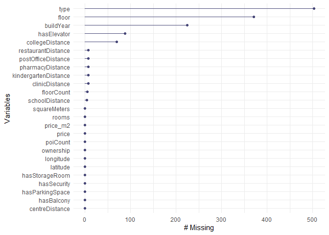

Imputację braków danych przeprowadzono z wykorzystaniem metody MICE (Multiple Imputation by Chained Equations). Dla zmiennych ilościowych (`floor`, `buildYear`, `collegeDistance`) zastosowano metodę predykcyjnego dopasowania średnich (PMM), natomiast dla zmiennej binarnej `hasElevator` wykorzystano regresję logistyczną. Macierz predyktorów zdefiniowano selektywnie, uwzględniając wyłącznie zmienne merytorycznie powiązane z imputowanymi cechami. W dalszej analizie wykorzystano kompletny zbiór danych po imputacji (`dane_imputed`).

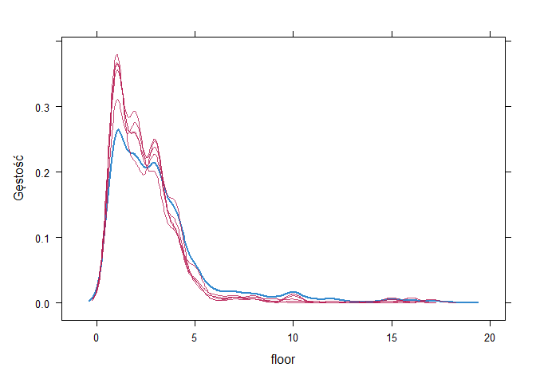

Wykres przedstawia porównanie rozkładów wartości obserwowanych i imputowanych zmiennej piętro. Rozkłady po imputacji zachowują strukturę danych pierwotnych, bez widocznej koncentracji imputowanych wartości w pojedynczych punktach ani przesunięcia zakresu zmienności.

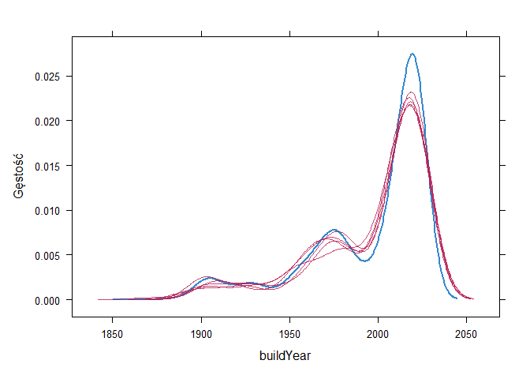

Wykres gęstości dla zmiennej rok budowy wskazuje, że imputowane wartości są zgodne z rozkładem obserwowanych danych. Nie zaobserwowano sztucznego wygładzenia ani generowania nierealistycznych wartości, co świadczy o poprawnym dopasowaniu procedury imputacji.

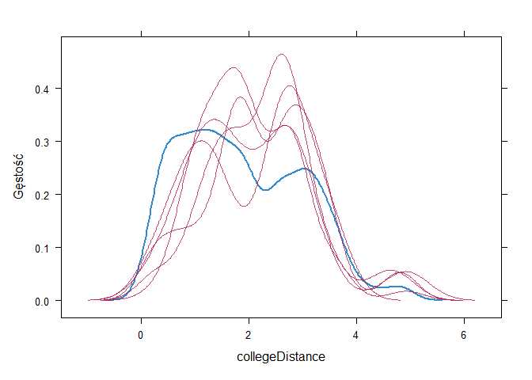

## Analiza esploracyjna danych

W niniejszym rozdziale przeprowadzono analizę eksploracyjną danych, koncentrując się na wizualizacji zależności pomiędzy ceną mieszkań a ich cechami ilościowymi, jakościowymi oraz lokalizacyjnymi, w tym rozmieszczeniu przestrzennym ofert.

### Analiza opisowa zmiennych ilościowych i dyskretnych

W niniejszym podrozdziale przedstawiono analizę opisową zmiennych ilościowych i dyskretnych wykorzystanych w dalszych etapach badania. Zaprezentowano podstawowe miary położenia, zróżnicowania oraz zakresy zmienności, co pozwala scharakteryzować strukturę danych przed przejściem do analizy wizualnej i wnioskowania statystycznego.

Statystyki opisowe (zmienne dyscretne)

| Zmienna | % kompletności | Średnia | Odch. std. | Min | Q1 | Mediana | Q3 | Max |
| --- | --- | --- | --- | --- | --- | --- | --- | --- |
| Liczba pokoi | 100.0 | 2.72 | 0.91 | 1 | 2 | 3 | 3 | 6 |
| Piętro | 99.7 | 2.99 | 2.49 | 1 | 1 | 2 | 4 | 18 |
| Liczba kondygnacji w budynku | 99.7 | 5.06 | 3.39 | 1 | 3 | 4 | 5 | 20 |
| Rok budowy | 99.9 | 1995.84 | 33.48 | 1870 | 1976 | 2012 | 2021 | 2024 |
| Liczba punktów POI w pobliżu | 100.0 | 18.18 | 25.85 | 0 | 5 | 10 | 19 | 148 |

Tabela prezentuje statystyki opisowe zmiennych dyskretnych, które cechują się niemal pełną kompletnością danych. Liczba pokoi i piętro mają niewielką zmienność i skoncentrowane rozkłady wokół wartości typowych dla mieszkań miejskich. Liczba kondygnacji oraz rok budowy wykazują większe zróżnicowanie, co odzwierciedla heterogeniczność zabudowy. Zmienna opisująca liczbę punktów POI w pobliżu charakteryzuje się bardzo dużym rozrzutem i prawostronną asymetrią, wskazując na silne zróżnicowanie lokalizacyjne ofert.

Statystyki opisowe (zmienne numeryczne)

| Zmienna | % kompletności | Średnia | Odch. std. | Min | Q1 | Mediana | Q3 | Max |
| --- | --- | --- | --- | --- | --- | --- | --- | --- |
| Powierzchnia mieszkania [m²] | 100 | 58.63 | 20.14 | 25.00 | 44.48 | 54.90 | 68.75 | 147.80 |
| Cena całkowita [PLN] | 100 | 891338.46 | 390898.19 | 415000.00 | 629000.00 | 765000.00 | 1024798.25 | 2499000.00 |
| Cena za metr kwadratowy [PLN/m²] | 100 | 15402.31 | 4373.61 | 9035.55 | 12024.63 | 14053.57 | 18386.03 | 29893.16 |

Tabela przedstawia statystyki opisowe zmiennych ilościowych i dyskretnych, dla których nie występują braki danych. Rozkład powierzchni mieszkań jest umiarkowanie zróżnicowany i prawostronnie asymetryczny. Ceny całkowite oraz ceny za metr kwadratowy charakteryzują się dużą zmiennością i wyraźną prawostronną asymetrią, co wskazuje na istotny wpływ drogich ofert na wartości średnie i uzasadnia dalszą analizę z wykorzystaniem miar pozycyjnych.

Statystyki opisowe (zmienne odlegościowe)

| Zmienna | % kompletności | Średnia | Odch. std. | Min | Q1 | Mediana | Q3 | Max |
| --- | --- | --- | --- | --- | --- | --- | --- | --- |
| Odległość od centrum [km] | 100.0 | 4.78 | 2.75 | 0.03 | 2.37 | 5.25 | 6.65 | 11.54 |
| Odległość do szkoły [km] | 99.8 | 0.46 | 0.38 | 0.02 | 0.22 | 0.37 | 0.55 | 4.82 |
| Odległość do przychodni [km] | 99.6 | 1.15 | 0.89 | 0.00 | 0.50 | 0.92 | 1.61 | 4.50 |
| Odległość do poczty [km] | 99.6 | 0.47 | 0.36 | 0.00 | 0.22 | 0.37 | 0.58 | 2.29 |
| Odległość do przedszkola [km] | 99.6 | 0.40 | 0.32 | 0.00 | 0.19 | 0.33 | 0.53 | 2.71 |
| Odległość do restauracji [km] | 99.6 | 0.33 | 0.29 | 0.00 | 0.13 | 0.23 | 0.45 | 1.86 |
| Odległość do uczelni [km] | 100.0 | 1.90 | 1.12 | 0.01 | 0.95 | 1.76 | 2.82 | 4.92 |
| Odległość do apteki [km] | 99.6 | 0.37 | 0.28 | 0.00 | 0.17 | 0.31 | 0.51 | 2.45 |

Tabela przedstawia statystyki opisowe zmiennych odległościowych, które charakteryzują się niemal pełną kompletnością danych. Odległość od centrum wykazuje największe zróżnicowanie spośród analizowanych zmiennych, co odzwierciedla przestrzenne rozproszenie ofert. Odległości do podstawowych usług i obiektów użyteczności publicznej są relatywnie niewielkie i skoncentrowane wokół niskich wartości, jednak w większości przypadków widoczna jest prawostronna asymetria rozkładów, wskazująca na obecność ofert położonych znacznie dalej od infrastruktury.

### Analiza opisowa zmiennych jakościowych

W niniejszym podrozdziale przeprowadzono analizę zmiennych jakościowych opisujących cechy techniczne mieszkań oraz elementy ich wyposażenia. Celem tej części analizy eksploracyjnej jest ocena kompletności danych, liczby kategorii oraz struktury częstości występowania poszczególnych cech, a także identyfikacja podstawowych zależności pomiędzy wybranymi zmiennymi jakościowymi.

Statystyki opisowe zmiennych jakościowych

| Zmienna | Liczba obserwacji | Liczba braków | % kompletności | Liczba kategorii |
| --- | --- | --- | --- | --- |
| hasBalcony | 1986 | 0 | 100.0 | 2 |
| hasElevator | 1986 | 0 | 100.0 | 2 |
| hasParkingSpace | 1986 | 0 | 100.0 | 2 |
| hasSecurity | 1986 | 0 | 100.0 | 2 |
| hasStorageRoom | 1986 | 0 | 100.0 | 2 |
| ownership | 1986 | 0 | 100.0 | 2 |
| type | 1986 | 503 | 74.7 | 3 |

Tabela przedstawia liczbę obserwacji, braki danych, poziom kompletności oraz liczbę kategorii dla zmiennych jakościowych. Zmienne cechują się wysoką kompletnością, a liczba kategorii jest zgodna z ich charakterem, co wskazuje na dobrą jakość danych.

Procent ‘tak’ w zmiennych binarnych

| Zmienna | Liczba obserwacji | Liczba braków | Liczba niebraków | Liczba ‘tak’ | % ‘tak’ |
| --- | --- | --- | --- | --- | --- |
| hasBalcony | 1986 | 0 | 1986 | 1160 | 58.4 |
| hasElevator | 1986 | 0 | 1986 | 1053 | 53.0 |
| hasParkingSpace | 1986 | 0 | 1986 | 239 | 12.0 |
| hasSecurity | 1986 | 0 | 1986 | 275 | 13.8 |
| hasStorageRoom | 1986 | 0 | 1986 | 681 | 34.3 |

Zestawienie prezentuje udział odpowiedzi pozytywnych w zmiennych binarnych opisujących wyposażenie mieszkań. Widoczne zróżnicowanie częstości występowania poszczególnych udogodnień wskazuje na ich potencjalną rolę w dalszej analizie ofert.

```
##
##  Pearson's Chi-squared test with Yates' continuity correction
##
## data:  tab_matrix
## X-squared = 35.651, df = 1, p-value = 2.36e-09
```

Tabela kontyngencji: Balkon vs Winda

| Balkon | Winda | Liczba obserwacji | % w wierszu |
| --- | --- | --- | --- |
| no | no | 454 | 55.0 |
| no | yes | 372 | 45.0 |
| yes | no | 479 | 41.3 |
| yes | yes | 681 | 58.7 |

Tabela kontyngencji oraz wynik testu chi-kwadrat wskazują na statystyczną zależność pomiędzy występowaniem balkonu i windy, co sugeruje współwystępowanie tych cech w analizowanych ofertach.

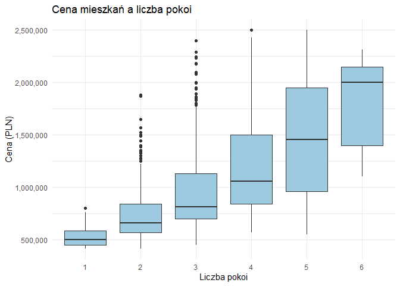

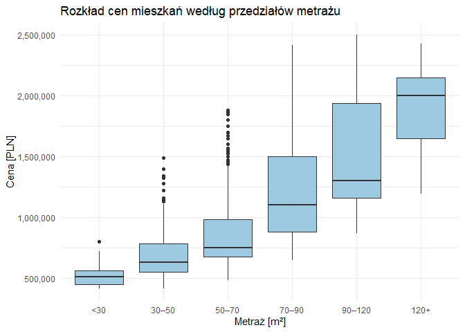

Ceny mieszkań rosną wraz z przechodzeniem do wyższych przedziałów metrażu, przy czym rozkłady w poszczególnych grupach wykazują rosnącą zmienność. Największe zróżnicowanie cen obserwowane jest dla mieszkań o dużej powierzchni.

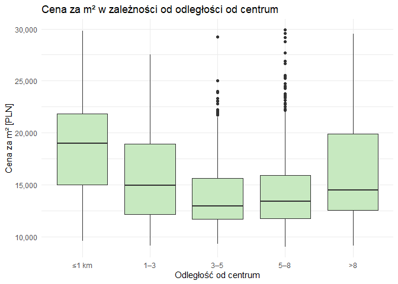

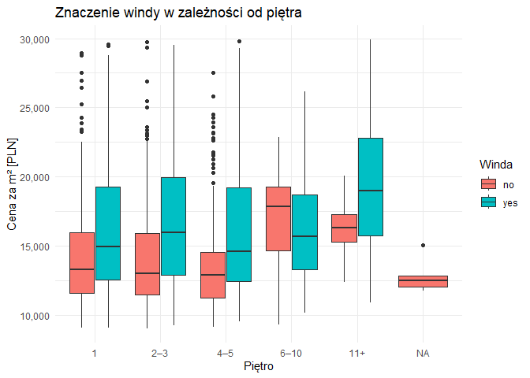

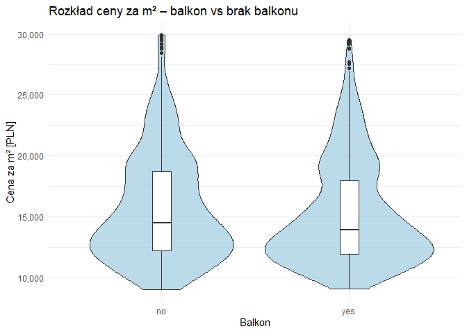

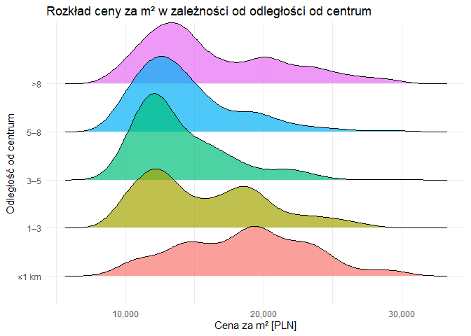

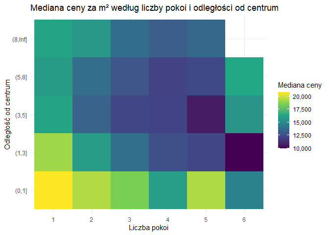

### Analiza przestrzenna rynku mieszkaniowego

W niniejszym podrozdziale przeprowadzono analizę przestrzenną rynku mieszkaniowego z wykorzystaniem współrzędnych geograficznych ofert. Analiza ta ma na celu rozpoznanie rozmieszczenia ofert w przestrzeni miejskiej, identyfikację obszarów koncentracji ogłoszeń oraz wstępną ocenę przestrzennego zróżnicowania cen za metr kwadratowy. Wizualizacje mapowe pozwalają na uzupełnienie wcześniejszych analiz opisowych i lepsze uchwycenie zależności przestrzennych niewidocznych w klasycznych zestawieniach tabelarycznych.

[interactive chart not shown]

Mapa punktowa przedstawia lokalizację poszczególnych ofert mieszkaniowych wraz z odpowiadającą im ceną za metr kwadratowy zakodowaną kolorem. Widoczne jest wyraźne zróżnicowanie przestrzenne cen, z obszarami skupiającymi oferty o wyższych oraz niższych poziomach cen, co wskazuje na istotną rolę lokalizacji w kształtowaniu wartości nieruchomości.

[interactive chart not shown]

Zastosowanie mechanizmu klastrowania markerów umożliwia czytelne przedstawienie rozmieszczenia ofert w obszarach o dużym zagęszczeniu punktów. Wizualizacja ta pozwala na łatwiejszą identyfikację rejonów o wysokiej liczbie ogłoszeń oraz ocenę, czy wysokie i niskie ceny występują w sposób przestrzennie skupiony.

[interactive chart not shown]

Mapa gęstości ofert prezentuje przestrzenną koncentrację ogłoszeń mieszkaniowych bez uwzględniania poziomu cen. Najciemniejsze obszary wskazują rejony o największej liczbie ofert, co może odzwierciedlać intensywność zabudowy mieszkaniowej lub większą aktywność rynku nieruchomości w tych lokalizacjach.

[interactive chart not shown]

Mapa ciepła ważona ceną za metr kwadratowy łączy informacje o lokalizacji ofert z poziomem cen, umożliwiając identyfikację obszarów charakteryzujących się wysokimi wartościami cenowymi. W przeciwieństwie do mapy gęstości ofert, wizualizacja ta akcentuje przestrzenne skupiska drogich nieruchomości, niezależnie od liczby występujących tam ogłoszeń.